# Analysis of Initial Small Subset of Cell Stress Compounds

This Notebook serves as a way to follow the analysis steps and decide what to take forward to the full investigation.

#### Load Packages

```r
library(tidygraph)
```

#### Analysis of input data

First we do some simple clustering of the input data to see if there are any underlying patterns in the transcriptomics data (for example, do they cluster based on cell stress or MoA?)

```r
# Load gene expression matrix
gex_matrix = read.csv("../Transcriptomics_Data/final_lincs_data.csv",row.names = 1)
head(gex_matrix)
```

|  | geldanamycin_HEPG2_24.h_10.µM | thapsigargin_HEPG2_6.h_10.µM | YC.1_HEPG2_24.h_20.µM | radicicol_HEPG2_24.h_10.0.um | YC.1_HEPG2_24.h_5.µM | geldanamycin_HEPG2_24.h_0.12.um | spiperone_HEPG2_24.h_10.µM | benzo.a.pyrene_VCAP_24.h_10.µM | tert.butylhydroquinone_JURKAT_6.h_1.µM | radicicol_HEPG2_24.h_0.12.um | spiperone_HEPG2_6.h_10.µM | VU.0418946.1_HEPG2_6.h_10.µM | tert.butylhydroquinone_JURKAT_24.h_500.nM | radicicol_HEPG2_24.h_1.11.um | geldanamycin_HEPG2_24.h_1.11.um | geldanamycin_HEPG2_24.h_1.11.µM | temozolomide_HEPG2_6.h_10.µM | radicicol_HEPG2_24.h_3.33.um | tert.butylhydroquinone_JURKAT_6.h_100.nM | tert.butylhydroquinone_JURKAT_6.h_500.nM | radicicol_HEPG2_24.h_0.04.um | geldanamycin_HEPG2_6.h_10.µM | brefeldin.a_HEPG2_6.h_10.µM | spiperone_HEPG2_24.h_3.µM | tert.butylhydroquinone_JURKAT_24.h_100.nM | tert.butylhydroquinone_JURKAT_6.h_10.µM | geldanamycin_HEPG2_24.h_0.37.µM | brefeldin.a_HEPG2_6.h_100.nM | tert.butylhydroquinone_JURKAT_24.h_10.µM | … |
| --- | --- | --- | --- | --- | --- | --- | --- | --- | --- | --- | --- | --- | --- | --- | --- | --- | --- | --- | --- | --- | --- | --- | --- | --- | --- | --- | --- | --- | --- | --- |
| 16 | -6.2474053 | -4.1792345 | 0.5482813 | -0.9487715 | 1.22131681 | -0.1302663 | -5.0079889 | -0.2276287 | -1.09437072 | -1.95500469 | -1.0751501 | -3.92360496 | 1.7425858 | -2.7719660 | -4.90461826 | -7.12740755 | 0.3906590 | -3.5168118 | -0.98260957 | -0.6315127 | -0.3987721 | -1.4305498 | -2.3279698 | 0.37973687 | 0.257906497 | 0.000807017 | -5.9054286 | -2.36721182 | -0.6369500 | … |
| 23 | 1.7086284 | -0.5000502 | 4.3238430 | 1.1715679 | 3.07058334 | -0.4300455 | 2.4023714 | -0.4383351 | 1.13559699 | -0.48823270 | -0.4076776 | 0.01381284 | -0.2233529 | 0.2032584 | 0.64689469 | 0.19715167 | 7.0107212 | 0.3062655 | -0.15127352 | 0.7037365 | 0.2868040 | 1.7606227 | -1.0198416 | 0.04142860 | -0.091556385 | 0.161094680 | 1.4560213 | -0.61222899 | 0.2240751 | … |
| 25 | -4.2174922 | -1.1968787 | -0.3220803 | -2.8768857 | -0.64537168 | 0.1789627 | 0.7285157 | 0.2045142 | -0.48674673 | -1.15855706 | 0.3608525 | -0.26568401 | -0.1624144 | -2.2515326 | -2.31664610 | -4.19429016 | 0.2531620 | -3.1076963 | -0.63956308 | -0.8413593 | 1.8687207 | -0.5416946 | 0.7295799 | -0.83776307 | 0.008359618 | -0.132945135 | -4.4460948 | 1.23057687 | -0.2610964 | … |
| 30 | 0.5704836 | 0.2277601 | -8.4137936 | 0.5179760 | -4.79534912 | 0.1916189 | -0.2110731 | -1.2614586 | -1.69161201 | 0.38529190 | 0.2289263 | -2.39128804 | 0.1001476 | 0.1948287 | -0.07323781 | -0.02306676 | 1.1408126 | -1.0563043 | -0.93199837 | -1.3502558 | 0.2536753 | -1.9737169 | -2.9508924 | 1.08004034 | -2.978457928 | 0.110623740 | 0.1496664 | -0.09790407 | 0.8461906 | … |
| 39 | -0.0893153 | 0.1643779 | 1.0739298 | -0.7990648 | -0.03334141 | -0.6419541 | 0.0833596 | 0.4734720 | 0.09640801 | -0.01718235 | -0.3417360 | 1.24660134 | -0.4640653 | 0.1008638 | 0.20290816 | 0.38723949 | -1.8394639 | 1.0794595 | 1.19681156 | -0.4867740 | 0.5800813 | 0.4128154 | -0.4875183 | 0.49661112 | 1.227491379 | -0.452458322 | 0.5014004 | 1.00125825 | 0.1422774 | … |
| 47 | 1.7399375 | 1.4978825 | 2.5024781 | -1.2329154 | 0.61647493 | -0.3545181 | -0.2815745 | 0.1080180 | -0.01178508 | 1.20852053 | -0.7232009 | 1.13380969 | 0.1952427 | 1.0825422 | 1.05843031 | 0.92205760 | 0.9762175 | -0.3110381 | -0.08575885 | -0.7387225 | 0.6113923 | -0.2295633 | -0.4406420 | 0.09252907 | 0.510344505 | -1.517525673 | 1.4854088 | 0.95501709 | -0.1143209 | … |

As shown above, we have 978 landmark genes and 50 signatures. This is what we are basing our clustering on.

Clustering:

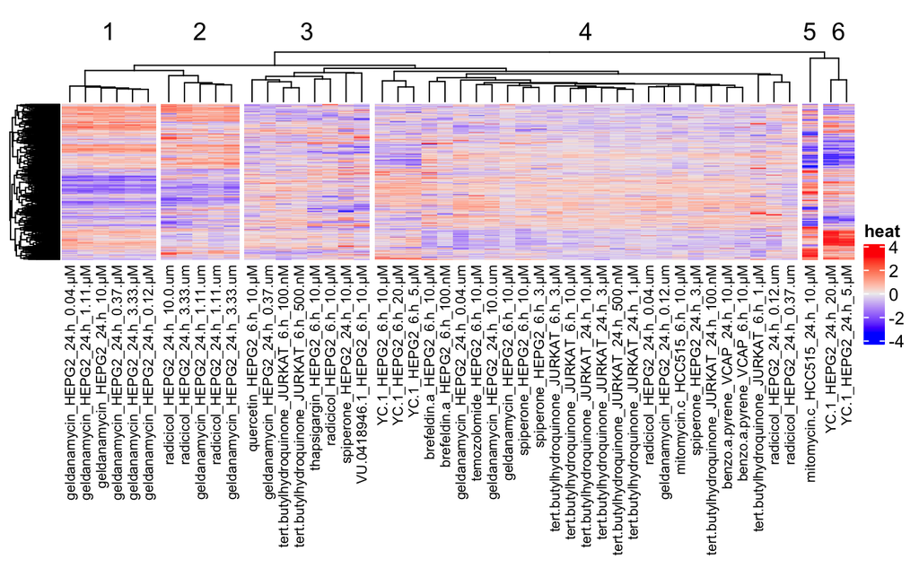

```r
# Scale
heat <- t(scale(t(gex_matrix)))

# Plot - seems to split nicely into roughly 6 clusters
Heatmap(heat, name = "heat",show_row_names=F, column_names_gp = grid::gpar(fontsize = 8),column_split=6)
```

Based on this simple and fast clustering we can see that the data can be roughly split into 6 clusters. Starting from the left hand side of the plot (cluster 1), it can be seen that the Geldanamycin response in HEPG2 produces a relatively stable response at different concentrations. Geldanamycin signatures are also present in cluster 2, which is almost identical to cluster 1 apart from the set of overexpressed genes towards the bottom of the plot.These are clustering to radicicol signatures in HEPG2 at 24h, which makes sense as both drugs are HSP90 inhibitors. Clusters 3 and 4 are roughly similar and contain a large amount of compounds, which could indicate a cell stress response rather than a separation due to differing MoAs. Interestingly, Mitomycin HCC515 at 24h and 10uM, and YC-1 in HEPG2 at 24h and 20 and 5 uM have particularly strong responses which is indicated by the darker colours.

Note that there are replicates at this stage which were combined for the purpose of Causal Reasoning analysis.

It will be interesting to compare how the compounds cluster on the signalling-protein level and see if this relates to the gene-expression level.

#### Analysis of CausalR results

CausalR results are subnetworks which we can use to perform enrichment and similarity analyses.

First we can perform enrichment analyses to see which pathways or cell stress mechanisms are inferred to be differentially regulated based on the dysregulated signalling proteins reasoned using a PPI network and the above gene expression data.

I first create a simple function to perform enrichment of an input gmt file

```r
enrichGMT = function(gmt_file,inferred_proteins,net_proteins){

  gmt_read = read.gmt(gmt_file)

  all_results = list()
  for(i in 1:length(gmt_read)){
    gene_set_name = names(gmt_read[i])
    gene_set = gmt_read[[i]]


    a = intersect(gene_set,inferred_proteins)
    b = setdiff(gene_set,inferred_proteins)
    c = setdiff(inferred_proteins,gene_set)
    d = setdiff(net_proteins,c(a,b,c))

    mat = matrix(data=c(length(a),length(b),length(c),length(d)),nrow=2,ncol=2)

    enrich = fisher.test(mat,alternative="greater")$p.value

    res = c(gene_set_name,paste0(a,collapse=", "),enrich)

    all_results[[i]] = t(data.frame(res))
  }

  results_df = data.frame(do.call("rbind",all_results))
  rownames(results_df) = NULL
  colnames(results_df) = c("Gene set", "Overlap", "pValue")
  results_df$pAdj = p.adjust(as.numeric(as.character(results_df$pValue)))

  return(results_df)
}
```

```r
# Get full network for background enrichment
net = read.csv("../Network_Data/omnipath_full_formatted.csv")
net_proteins = unique(c(as.character(net$source)),as.character(net$target))
universe = AnnotationDbi::select(keys=net_proteins,
                        org.Hs.eg.db,
                        columns=c("SYMBOL","ENTREZID"),
                        keytype="SYMBOL"
                        )$ENTREZID

# List directories
causalr_res_dirs = list.dirs("../Results/CausalR",full.names = T)
causalr_res_dirs = causalr_res_dirs[2:50] # get rid of root dir

# Loop over dirs
for(dir in causalr_res_dirs){

  # Network is contained in .sif files
  sif_files = list.files(path=dir,pattern=".sif",full.names = T)

  # Combine to make one network and save for visualisation later on
  net_full <- do.call("rbind", lapply(sif_files, FUN = function(file) {
    read.table(file, header=F, sep="\t")
  }))

  # Save network
  fname = paste0(dir,"/full_net.siff") # 2 fs so we don't combine it again and again!
  write.table(net_full,fname,quote = F,sep = "\t",row.names = F, col.names = F)

  # Extract signalling proteins
  inferred_proteins = unique(c(as.character(net_full$V1),as.character(net_full$V3)))

  # Convert to Entrez id
  conversion = AnnotationDbi::select(keys=inferred_proteins,
                        org.Hs.eg.db,
                        columns=c("SYMBOL","ENTREZID"),
                        keytype="SYMBOL"
                        )$ENTREZID

  # Do the enrichment of Reactome pathways
  enrichment = enrichPathway(conversion,
                organism="human",
                universe=universe,
                readable=T)

  # Save table
  fname = paste0(dir,"/reactome_enrichment.csv")
  write.csv(enrichment@result,fname)

  # Do the enrichment of the curated gene sets
  gmt_file = "../../gmt/allsigthdd_10282020.gmt"
  allsigthdd_res = enrichGMT(gmt_file,inferred_proteins,net_proteins)
  fname = paste0(dir,"/allsigthdd_enrichment.csv")
  write.csv(allsigthdd_res,fname)

  gmt_file = "../../gmt/EXPERIMENTAL_directional_consensus_signatures_V1_EXPERIMENTAL.gmt"
  experimental_res = enrichGMT(gmt_file,inferred_proteins,net_proteins)
  fname = paste0(dir,"/experimental_enrichment.csv")
  write.csv(experimental_res,fname)

  gmt_file = "../../gmt/nondirectional_consensus_signatures_V1_20200807.gmt"
  nondirectional_res = enrichGMT(gmt_file,inferred_proteins,net_proteins)
  fname = paste0(dir,"/nondirectional_enrichment.csv")
  write.csv(nondirectional_res,fname)
}
```

Now that we have the enrichment results we can compare the output networks based on (a) enrichment (b) presence of nodes In theory, compounds which induce similar cell stress responses will have similar enriched pathways and nodes in the networks.

First we can perform a Jaccard coefficient analysis of networks, where higher Jaccard coefficient = more similar networks, and can thus be inferred to induce a similar response in cellular signalling pathways.

```r
# List directories
causalr_res_dirs = list.dirs("../Results/CausalR",full.names = T)
causalr_res_dirs = causalr_res_dirs[2:50] # get rid of root dir

# Pairwise loop over dirs
jc_results = data.frame()
for(dir1 in causalr_res_dirs){
  for(dir2 in causalr_res_dirs){

    if(dir1==dir2){ # if same then jc = 1 (diagonal)
      jc = 1
      exp1 = strsplit(dir1,"/")[[1]][4]
      exp2 = strsplit(dir2,"/")[[1]][4]
      # Create row
      row = t(data.frame(c(exp1,exp2,jc)))
      jc_results = rbind(jc_results,row)
      next
    }

    # Network is contained in .sif files
    net_full_1 = read.table(paste0(dir1,"/full_net.siff"),sep="\t")
    # Extract signalling proteins
    inferred_proteins_1 = unique(c(as.character(net_full_1$V1),as.character(net_full_1$V3)))

    # Network is contained in .sif files
    net_full_2 = read.table(paste0(dir2,"/full_net.siff"),sep="\t")
    # Extract signalling proteins
    inferred_proteins_2 = unique(c(as.character(net_full_2$V1),as.character(net_full_2$V3)))

    # Compute jc
    jc = length(intersect(inferred_proteins_1,inferred_proteins_2))/length(union(inferred_proteins_1,inferred_proteins_2))

    # Get experimental conditions
    exp1 = strsplit(dir1,"/")[[1]][4]
    exp2 = strsplit(dir2,"/")[[1]][4]

    # Create row
    row = t(data.frame(c(exp1,exp2,jc)))
    jc_results = rbind(jc_results,row)
  }
}

# Tidy and save
rownames(jc_results) = NULL
colnames(jc_results) = c("exp1","exp2","Jc")
jc_results$Jc = as.numeric(as.character(jc_results$Jc))
write.csv(jc_results,"../Results/CausalR/network_jaccards.csv")

# Now do the corr mat
# Reshape
jc_results_wide = reshape(jc_results, idvar = "exp1", timevar = "exp2", direction = "wide")
rownames(jc_results_wide) = jc_results_wide$exp1
jc_results_wide$exp1 = NULL
jc_results_wide = as.matrix.data.frame(jc_results_wide)

# Cluster and plot
jc.dist <- as.dist(1 - jc_results_wide) # turn into dissimilarity matrix
tree <- hclust(jc.dist, method="complete") # cluster
dend = as.dendrogram(tree)
color.scheme <- (brewer.pal(10,"Reds")) # generate the color scheme to use
```

```
n too large, allowed maximum for palette Reds is 9
Returning the palette you asked for with that many colors
```

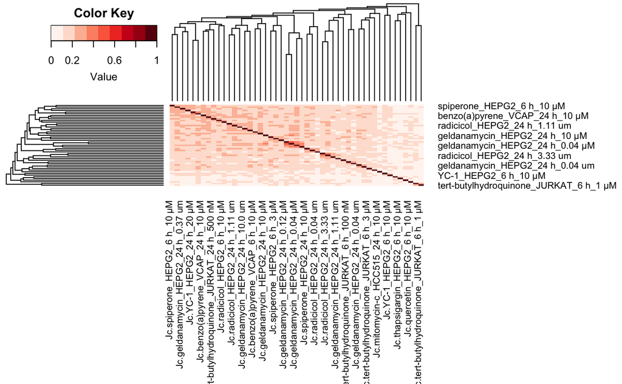

```r
heatmap.2(jc_results_wide,
          Rowv = ladderize(dend),
          Colv = ladderize(dend),
          dendrogram = "both",
          revC = TRUE,  # rev column order of dendrogram so conforms to natural representation
          trace = "none",
          density.info = "none",
          col = color.scheme, key = T,
          margins=c(14,14))
```

Now let’s compare the enrichment results. We will use the custom gene sets rather than the Reactome results, as we mostly care about the cell stress mechanism. We use the same principle as above but instead of computing Jaccard coefficients between two experiment’s network nodes, we are computing correlation coefficients between cell stress mechanism gene sets.

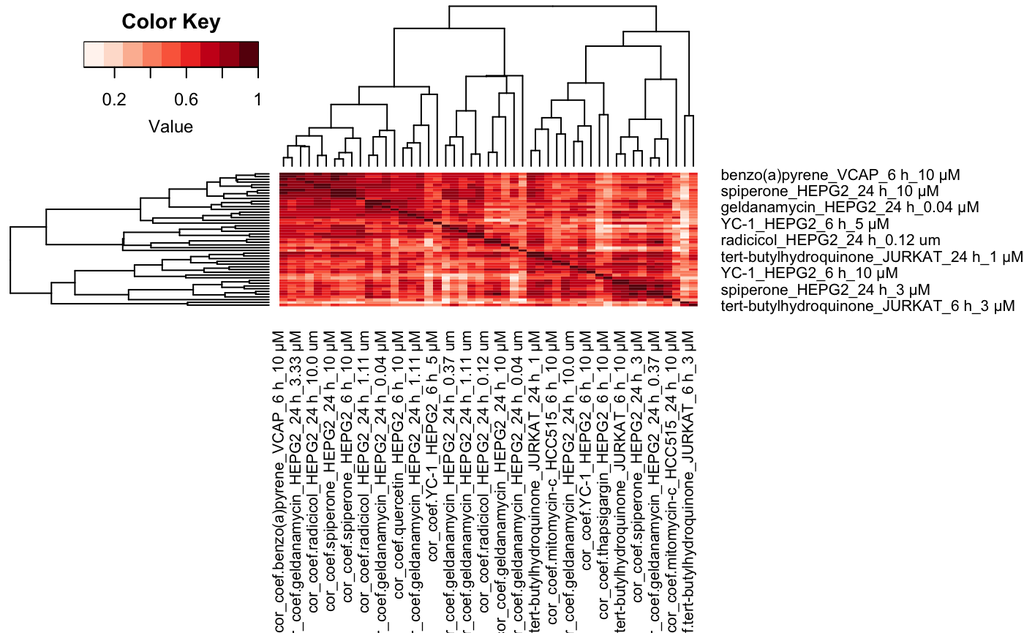

Other analysis can be done as well e.g. time or dose analysis, examining if any particular protein drivers are over-represented in certain cell stress classes, etc.